# TP 2 : Introduction au Machine Learning

## Partie 1 : Perceptron et K-NN

```python
import numpy as np # pour manipuler des valeurs numériques
import pandas as pd # pour manipuler des dataframes
import matplotlib.pyplot as plt # pour afficher des graphiques
import seaborn as sns # graphique spécialement fait pour faire de la data vizualisation
```

[output not shown]

Nous allons travailler avec un jeu de données portant sur des vins, qui est téléchargeable depuis pamplemousse. On veillera à ne pas ouvrir le fichier csv avec Excel pour l’enregistrer ensuite, car Excel peut altérer le fichier. Nous le chargeons sous la forme d’une DataFrame pandas et affichons ses 5 premières lignes comme suit.

### Q1.

Question 1. — Examiner la DataFrame data. Combien d’exemples et combien de variables le jeu de données contient-il?

```python
# charger les données
data = pd.read_csv('data/wine_dataset.csv', sep = ";")
# regarder les 5 premières lignes de data
data.head(5)
```

|  | fixed acidity | volatile acidity | citric acid | residual sugar | chlorides | free sulfur dioxide | total sulfur dioxide | density | pH | sulphates | alcohol | quality | color |
| --- | --- | --- | --- | --- | --- | --- | --- | --- | --- | --- | --- | --- | --- |
| 0 | 7.0 | 0.27 | 0.36 | 20.7 | 0.045 | 45.0 | 170.0 | 1.0010 | 3.00 | 0.45 | 8.8 | 6 | 0 |
| 1 | 6.3 | 0.30 | 0.34 | 1.6 | 0.049 | 14.0 | 132.0 | 0.9940 | 3.30 | 0.49 | 9.5 | 6 | 0 |
| 2 | 8.1 | 0.28 | 0.40 | 6.9 | 0.050 | 30.0 | 97.0 | 0.9951 | 3.26 | 0.44 | 10.1 | 6 | 0 |
| 3 | 7.2 | 0.23 | 0.32 | 8.5 | 0.058 | 47.0 | 186.0 | 0.9956 | 3.19 | 0.40 | 9.9 | 6 | 0 |
| 4 | 7.2 | 0.23 | 0.32 | 8.5 | 0.058 | 47.0 | 186.0 | 0.9956 | 3.19 | 0.40 | 9.9 | 6 | 0 |

Combien avons-nous de **variables** et d'**exemples** ?

```python
print(data.shape)
print("Il y a {} exemples (données), et {} descripteurs (variables)".format(len(data), len(data.columns)))
```

```
(6497, 13)
Il y a 6497 exemples (données), et 13 descripteurs (variables)
```

Le jeu de données contient **6497 exemples** (lignes) et **13 variables** (colonnes)

On souhaite apprendre à prédire le type de vin (rouge ou blanc) à partir des propriétés chimiques. La variable quality n’est pas une propriété chimique, mais une note subjective donnée par des personnes ayant goûté le vin; elle n’est pas pertinente pour notre problème; nous allons donc la supprimer. Pandas permet de manipuler (en l’occurrence, supprimer) les colonnes en les désignant par leurs noms.

```python
data = data.drop(columns=['quality'])
```

On l'enlève car elle est subjective.

D’anciennes versions de Pandas peuvent renvoyer une erreur pour la commande ci-dessus. On pourra alors essayer data.drop([’quality’],axis=1).

Avant de construire des prédicteurs, nous souhaitons sélectionner un petit nombre de variables explicatives (disons quatre): celles qui semblent les plus prometteuses pour la prédiction du type de vin. Pour la variable fixed_acidity par exemple, nous pouvons visualiser sa répartition pour chaque type de vin de la façon suivante

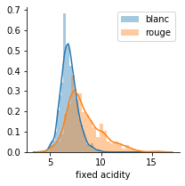

```python
g = sns.FacetGrid(data=data, hue='color')
g.map(sns.distplot, 'fixed acidity')#.add_legend()
plt.legend(['blanc','rouge']) #blanc = 0, rouge = 1
plt.show()
```

On peut également tracer plusieurs graphes dans une même figure. Il faut d’abord donner un nom à la figure (fig ci-dessous), et ensuite déclarer chaque nouvelle sous-figure à l’aide de fig.add_subplot().

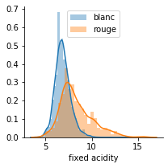

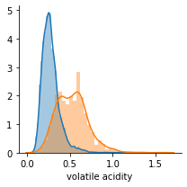

```python
#fig = plt.figure()
#fig.add_subplot()
g = sns.FacetGrid(data=data, hue='color')
g.map(sns.distplot, 'fixed acidity')#.add_legend()
fig.add_subplot()
plt.legend(['blanc','rouge'],loc="upper center")
g = sns.FacetGrid(data=data, hue='color')
g.map(sns.distplot, 'volatile acidity')#.add_legend()
```

### Q2.

Question 2. — Produire une figure qui contient les visualisations pour chaque variable explicative. On pourra faire intervenir une boule for, ainsi que data.columns qui donne la liste des noms des variables.

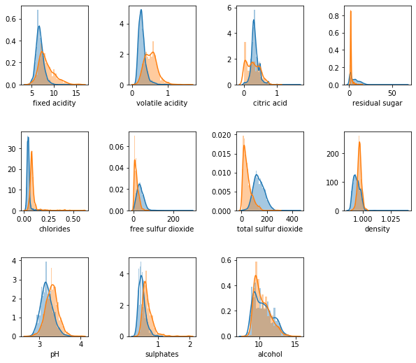

```python
fig = plt.figure(figsize=(10,12))
fig.subplots_adjust(wspace=0.6, hspace=0.6)

for i, col in enumerate(data.columns.drop('color')):
    ax = fig.add_subplot(4,4,i+1)
    g = sns.FacetGrid(data=data, hue='color')
    g.map(sns.distplot, col, ax=ax)
    plt.close()
#plt.legend(['blanc','rouge'],loc="right")
plt.show()
```

Fixed acidity pour les vins blancs (en bleu) a peu de variance.

### Q3.

Question 3. — En s’appuyant sur les figures obtenues, choisir quatre variables qui semblent les plus prometteuses pour la prédiction du type de vin. Créer une DataFrame data_reduced ne contenant que ces variables sélectionnées ainsi que la variable à prédire. On pourra utiliser la syntaxe suivante.

**Sélection de variables** ("à vue d'oeil") : Il semble raisonnable de sélectionner les variables explicatives `volatile_acidity`, `chlorides`, `free_sulfur_dioxide` et `total_sulfur_dioxide`.

Ce sont les variables qui arrivent à bien nous faire déterminer s'il s'agit d'un vin blanc et d'un vin rouge. Plusieurs possibilités de choix.

```python
# Hu
data_reduced = data[['volatile acidity',
                     'chlorides',
                     'free sulfur dioxide',
                     'total sulfur dioxide',
                     'color']] # ne pas oublier notre "y"
# Autre chargé de TD : Flore
#data_reduced = data[['volatile acidity','residual sugar', \
#                     'chlorides', 'total sulfur dioxide', 'color']]
```

Nous allons à présent séparer le jeu de données en des échantillons de test et d’apprentissage. Nous pouvons pour cela faire appel à une fonction dédiée fournie par scikit-learn qui s’occupe également de mélanger l’ordre des exemples.

Construisons notre base de **test** et notre base d'**apprentissage** :

```python
from sklearn.model_selection import train_test_split
X = data_reduced.drop(columns='color')
y = data_reduced['color']
X_train, X_test, y_train, y_test = train_test_split(X, y)
```

```python
print(X_train.head())
print(y_train.head())
print(X_test.head())
print(y_test.head())
print("La proportion des données de test est {}.".format(len(y_test)/(len(y_train)+len(y_test))))
print("Il y a {} exemples dans le jeu d'entrainement".format(len(y_train)))
```

```
      volatile acidity  chlorides  free sulfur dioxide  total sulfur dioxide
5777              0.60      0.076                 18.0                  88.0
1358              0.35      0.048                 35.0                 103.0
896               0.18      0.047                 52.0                 242.0
4099              0.50      0.059                 19.0                 112.0
1991              0.20      0.056                 53.0                 212.5
5777    1
1358    0
896     0
4099    0
1991    0
Name: color, dtype: int64
      volatile acidity  chlorides  free sulfur dioxide  total sulfur dioxide
4711             0.205      0.051                 31.0                 115.0
1472             0.210      0.052                  6.0                  48.0
4566             0.360      0.030                 43.5                 171.0
1306             0.240      0.047                 34.0                 105.0
5904             0.290      0.063                 13.0                  27.0
4711    0
1472    0
4566    0
1306    0
5904    1
Name: color, dtype: int64
La proportion des données de test est 0.2501154378944128.
Il y a 4872 exemples dans le jeu d'entrainement
```

75 % sont dans l'entraînement. 25 % dans le jeu de test

### Q4.

Question 4. — Observer les échantillons obtenus et déterminer le ratio de leurs tailles. Nous allons à présent entraîner une régression logistique.

```python
help(train_test_split)
```

[output not shown]

[output cut: 31 more lines]

```
    ...
    >>> X_train
    array([[4, 5],
           [0, 1],
           [6, 7]])
    >>> y_train
    [2, 0, 3]
    >>> X_test
    array([[2, 3],
           [8, 9]])
    >>> y_test
    [1, 4]

    >>> train_test_split(y, shuffle=False)
    [[0, 1, 2], [3, 4]]
```

D'après la documentation de la fonction `train_test_split`, les proporitions des échantillons d'apprentissage et de test sont de 75% - 25%. Faisons une petite vérification :

- train-set :

```python
print(y_train.size / (y_train.size + y_test.size))
```

```
0.7498845621055872
```

- test-set :

```python
print(y_test.size / (y_train.size + y_test.size))
```

```
0.2501154378944128
```

Entraînons une **régression logistique** :

```python
from sklearn.linear_model import LogisticRegression

f = LogisticRegression()
f.fit(X_train, y_train)

print("Le score de f sur le jeu de test vaut {}.".format(f.score(X_test, y_test)))
print("Le score de f sur le jeu d'entrainement' vaut {}.".format(f.score(X_train, y_train)))
```

```
Le score de f sur le jeu de test vaut 0.9618461538461538.
Le score de f sur le jeu d'entrainement' vaut 0.9622331691297209.
```

L'erreur sur jeu de test est censée être plus élevée que sur jeu d'entraînement (et donc le score plus faible) mais ce n'est pas toujours le cas.

### Q5.

Question 5. — Afficher les erreurs d’apprentissage et de test du prédicteur construit. On pensera à utiliser la fonction f.score().

Regardons les erreurs d'apprentissage et de test.

**Remarque** : f.score() nous donne la métrique **accuracy** qui est tout simplement la proportion de bonnes prédictions

```python
print("Erreur d\'apprentissage :", 1-f.score(X_train, y_train))
print("Erreur de test :", 1-f.score(X_test, y_test))
```

```
Erreur d'apprentissage : 0.0377668308702791
Erreur de test : 0.038153846153846205
```

```python
print("Score sur le train-set :", f.score(X_train, y_train))
print("Score sur le test-set :", f.score(X_test, y_test))
```

```
Score sur le train-set : 0.9622331691297209
Score sur le test-set : 0.9618461538461538
```

Dans la suite, on pourra considérer directement le score plutôt que l'erreur.

### Q6.

Question 6. — Entraîner également un prédicteur Perceptron qu’on pourra charger à l’aide de la commande Perceptron ainsi que des prédicteurs kNN (pour différentes valeurs de k). Comparer les résultats. Nous allons à présent consulter, par exemple pour le prédicteur f, la matrice de confusion calculée sur l’échantillon de test. pd.crosstab(y_test,f.predict(X_test))

```python
from sklearn.linear_model import Perceptron
perceptron = Perceptron()
perceptron.fit(X_train, y_train) # on entraine p sur le jeu d'entrainement
print("Le score de perceptron sur le jeu de test vaut {}.".format(p.score(X_test, y_test)))
print("Le score de perceptron sur le jeu d'entrainement' vaut {}.".format(p.score(X_train, y_train)))
```

[output not shown]

La régression logistique semble plus performante que le perceptron. Essayons maintenant un k-NN avec $k \in\{1, \cdots, 19\}$ :

```
meilleur k sur les données de test : 8
Score de test du meilleur prédicteur kNN : 0.9353846153846154
```

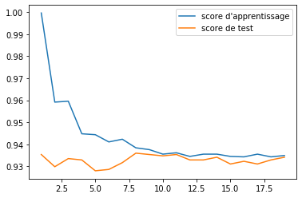

```python
#François Hu

from sklearn.neighbors import KNeighborsClassifier

knn = {}
score_train = []
score_test = []

k_range = range(1,20) #k plus proches voisins

for k in k_range:
    knn[k] =  KNeighborsClassifier(n_neighbors=k) #grille de 10 par défaut ?
    knn[k].fit(X_train,y_train) #on fait le knn sur les données d'entraînenement
    score_train.append(knn[k].score(X_train,y_train))
    score_test.append(knn[k].score(X_test,y_test))

k_best = np.argmax(score_test) + 1
print('meilleur k sur les données de test :', k_best)
print('Score de test du meilleur prédicteur kNN :',score_test[k_best])

plt.plot(list(k_range),score_train,label='score d\'apprentissage')
plt.plot(list(k_range),score_test,label='score de test')
plt.legend()
plt.show()
```

Le score est moins bon que celui de la régression logistique, et meilleur que celui du perceptron. La régression logistique reste donc pour l'instant imbattable.

```
Le score de kkn_1 sur le jeu de test vaut 0.9353846153846154.
```

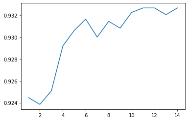

```python
# Solène Gaucher : méthode alternative
from sklearn.neighbors import KNeighborsClassifier
from sklearn.model_selection import GridSearchCV

param_grid = {'n_neighbors': np.arange(1, 15)}
knn = KNeighborsClassifier()
knn_cv = GridSearchCV(knn, param_grid, cv=10) # on estime les scores par validation
                                              # croisée à 10 blocs
knn_cv.fit(X_train, y_train) # on calcule les scores par validation croisée sur les
                                      # données d'entrainement

plt.plot(range(1, 15),knn_cv.cv_results_['mean_test_score'])

knn_1 = KNeighborsClassifier(n_neighbors = 1)
knn_1.fit(X_train,y_train)
print("Le score de kkn_1 sur le jeu de test vaut {}.".format(knn_1.score(X_test, y_test)))
```

### Q7.

Question 7. — Expliquer ce que représente la matrice de confusion.

**Rappel :**

- 0 = vin blanc
- 1 = vin rouge

```python
pd.crosstab(y_test, f.predict(X_test))
# crosstab est plus général que la matrice de confusion.
```

| col_0 color | 0 | 1 |
| --- | --- | --- |
| 0 | 1198 | 19 |
| 1 | 43 | 365 |

Dans la matrice de confusion, les lignes correspondent aux étiquettes réelles, et les colonnes aux étiquettes prédites.

|  | Y_hat=0 | Y_hat=1 |
| --- | --- | --- |
| Y = 0 | X | X |
| Y = 1 | X | X |

On remarque remarque qu'en proportition, un vin rouge ($y = 1$) est plus souvent prédit comme vin blanc ($\hat y = 0$) que l'inverse.

On remarque en consultant la matrice de confusion que l’échantillon de test contient nettement plus de vins blancs que de vins rouges. Ce n'est pas grave si la proportion de vin blanc est la même dans le test et dans le témoin et on n'a pas besoin d'avoir moins d'erreur pour prédire un vin rouge qu'un vin blanc. Par contre si on veut détecter tout le temps les vins rouges, ça peut être problématique. => On en déduit que lorsqu’on évalue la qualité des prédicteurs avec l’échantillon de test, la justesse des prédicteurs sur les vins blancs influence davantage le score que la justesse sur les vins rouges.

### Q8.

Question 8. — À partir de X_test et y_test, construire un sous-échantillon de test (X*test* et y*test*) qui contienne des vins rouges et blancs en quantités égales. On pourra faire appel à la fonction resample, dont on pourra consulter la documentation.

```python
# François Hu
from sklearn.utils import resample, shuffle

def balanced_data(X, y):
    # 0 : white
    # 1 : red
    label_counts = y.value_counts()
    X_white = X[y==0]
    y_white = y[y==0]
    X_less_white, y_less_white = resample(X_white,
                                          y_white,
                                          n_samples=label_counts[1],
                                          replace=False)
    X_ = pd.concat([X_less_white, X[y==1]])
    y_ = pd.concat([y_less_white, y[y==1]])
    X_, y_ = shuffle(X_,y_)
    return(X_, y_)

X_test_, y_test_ = balanced_data(X_test, y_test)
print(y_test_.value_counts())
```

```
1    408
0    408
Name: color, dtype: int64
```

```python
# On calcule le score de la régression linéaire f sur le jeu de données test
#(sans cross-valid)
print("Le score de f sur le jeu test (non équilibré) vaut {}.".format(f.score(X_test, y_test)))

# On calcule le score de la régression linéaire f sur le jeu de données test_
print("Le score de f sur le jeu test_ (équilibré) vaut {}.".format(f.score(X_test_, y_test_)))
```

```
Le score de f sur le jeu test (non équilibré) vaut 0.9618461538461538.
Le score de f sur le jeu test_ (équilibré) vaut 0.9375.
```

Le score est plus faible sur le nouveau jeu de données test_ (contenant la même proportion de vins blancs et de vins rouge) que sur le jeu test originel, ou de manière équivalent l'erreur est plus importante. Les vins blancs sont beaucoup plus nombreux que les vins rouges dans le jeu de données d'entrainement, et l'algorithme, qui est entrainé pour minimiser l'erreur empirique de ce jeu de données, sera moins performant.

De manière générale, pour que l'algorithme fonctionne correctement, les distributions des données d'entrainement et de test doivent être semblables.

=> Il faut autant de vin rouge que de vin blanc dans le jeu de test et d'entraînement. On augmente artificiellement le nombre de vin rouge.

```python
# Solene Gaucher : méthode alternative

# On sépare le jeu de test entre vins rouges et blancs
index_test_blanc = (y_test == 0)
X_test_blanc = X_test.loc[index_test_blanc]
y_test_blanc = y_test.loc[index_test_blanc]
X_test_rouge = X_test.loc[-index_test_blanc]
y_test_rouge = y_test.loc[-index_test_blanc]
nbr_train_blanc = len(y_train == 0)
nbr_blanc = len(y_test_blanc) # nombre de vins blancs

# On augmente artificiellement le nombre de vin rouge à l'aide de la fonction resample
X_test_rouge_, y_test_rouge_ = resample(X_test_rouge, y_test_rouge, \
                                        n_samples = nbr_train_blanc)

# On crée un nouveau jeu test_ comprenant autant de vins rouges que de vins blancs
X_test_ = pd.concat([X_test_blanc, X_test_rouge_])
y_test_ = pd.concat([y_test_blanc, y_test_rouge_])

# On calcule le score de la régression linéaire f sur le jeu de données test_
print("Le score de f sur le jeu test_ vaut {}.".format(f.score(X_test_, y_test_)))

#Rq il y a une erreur à un endroit, il aurait fallu mettre test au lieu de train à un endroit ou l'inverse...
```

```
Le score de f sur le jeu test_ vaut 0.9162424043356873.
```

### Q9.

Question 9. — Évaluer sur ce sous-échantillon la qualité des prédicteurs construits. Commenter les résultats.

```python
print('TEST (non équilibré) :')
print('Régression logistique :', f.score(X_test, y_test))
print('Peceptron :', perceptron.score(X_test, y_test))
print('Meilleur kNN :',knn[k_best].score(X_test, y_test))

print('\nTEST_ (équilibré) :')
print('Régression logistique :', f.score(X_test_, y_test_))
print('Peceptron :', perceptron.score(X_test_, y_test_))
print('Meilleur kNN :',knn[k_best].score(X_test_, y_test_))
```

```
TEST (non équilibré) :
Régression logistique : 0.9618461538461538
Peceptron : 0.8812307692307693
Meilleur kNN : 0.936

TEST_ (équilibré) :
Régression logistique : 0.9162424043356873
Peceptron : 0.6301527344391525
Meilleur kNN : 0.8375759566431269
```

Lorsque l'échantillon de test contient autant de vins rouges que de vins blancs, le score de chaque prédicteur est inférieur.

### Q10.

Question 10. — De la même manière, créer un sous-échantillons d’apprentissage X*train* et y*train*. Entraîner les prédicteurs sur ce sous-échantillon et observer leurs scores. Commenter.

```python
# Hu
X_train_, y_train_ = balanced_data(X_train, y_train)
print(y_train_.value_counts())
```

```
1    1191
0    1191
Name: color, dtype: int64
```

```python
f_ = LogisticRegression()
f_.fit(X_train_, y_train_)

print('TEST (avec train équilibré) :')
print('Régression logistique:', f_.score(X_test_,y_test_))

perceptron_ = Perceptron()
perceptron_.fit(X_train_,y_train_)
print('Perceptron:', perceptron_.score(X_test_,y_test_))

knn_ = {}
score_train = []
score_test = []
k_range = range(1, 20)
for k in k_range:
    knn_[k] =  KNeighborsClassifier(n_neighbors=k)
    knn_[k].fit(X_train_,y_train_)
    score_test.append(knn_[k].score(X_test_,y_test_))
k_best = np.argmax(score_test)
print('Meilleur kNN:', score_test[k_best])
```

```
TEST (avec train équilibré) :
Régression logistique: 0.9489242897027427
Perceptron: 0.9152570208572837
Meilleur kNN: 0.9031039579569716
```

TEST (non équilibré) : Régression logistique : 0.9618461538461538 Peceptron : 0.8812307692307693 Meilleur kNN : 0.936

TEST_ (équilibré) : Régression logistique : 0.9162424043356873 Peceptron : 0.6301527344391525 Meilleur kNN : 0.8375759566431269

Le score sur le jeu test équilibré de la fonction f_, entrainée sur des données équilibrées, est meilleur que celui de f, entrainé sur des données déséquilibrées. On voit qu'il est important que les données de test et d'entrainement aient la même distribution.

Il faut augmenter artificiellement les données les données APRES la séparation entre jeu d'entraînement et jeu de test.

```python
# Solene Gaucher

# On sépare le jeu d'entrainement entre vins rouges et blancs pour le jeu d'entrainement
index_train_blanc = (y_train == 0)
X_train_blanc = X_train.loc[index_train_blanc]
y_train_blanc = y_train.loc[index_train_blanc]
X_train_rouge = X_train.loc[-index_train_blanc]
y_train_rouge = y_train.loc[-index_train_blanc]

nbr_train_blanc = len(y_train_blanc) # nombre de vins blancs

# On augmente artificiellement le nombre de vin rouge à l'aide de la fonction resample
X_train_rouge_, y_train_rouge_ = resample(X_train_rouge, y_train_rouge,\
                                          n_samples = nbr_train_blanc)

# On crée un nouveau jeu train_ comprenant autant de vins rouges que de vins blancs
X_train_ = pd.concat([X_train_blanc, X_train_rouge_])
y_train_ = pd.concat([y_train_blanc, y_train_rouge_])

# On entraine une régression logistique sur le nouveau jeu d'entrainement train_
f_ = LogisticRegression()
f_.fit(X_train_, y_train_) # on entraine f_ sur le jeu d'entrainement equilibre
print("Le score de f_ sur le jeu d'entrainement train_ vaut {}.".\
      format(f_.score(X_train_, y_train_)))

# On calcule le score de la régression linéaire f_ sur le jeu de données test equilibré
print("Le score de f_ sur le jeu test_ vaut {}.".format(f_.score(X_test_, y_test_)))
```

```
Le score de f_ sur le jeu d'entrainement train_ vaut 0.9614235262157023.
Le score de f_ sur le jeu test_ vaut 0.9439973723107242.
```

### Q11.

Question 11. — Entraîner les estimateurs en utilisant l’ensemble des variables explicatives initialement disponibles. Commenter les résultats.

Régression logistique

```python
# Solène Gaucher

X_c_train, X_c_test, y_c_train, y_c_test = train_test_split(data.drop(columns='color')\
                                                    ,data.color)

# Reg logistique
f_c = LogisticRegression()
f_c.fit(X_c_train, y_c_train)
print("Le score de f_c sur le jeu de test vaut {}.".format(f_c.score(X_c_test, y_c_test)))
print("Le score de f_c sur le jeu d'entrainement' vaut {}.".format(f_c.score(X_c_train, y_c_train)))
```

```
Le score de f_c sur le jeu de test vaut 0.9741538461538461.
Le score de f_c sur le jeu d'entrainement' vaut 0.9819376026272578.
```

[output not shown]

Le score de la regression logistique augmente légèrement lorsqu'on prend en compte les 11 variables explicatives, au lieu des 4 choisies au début. On remarque cependant que les 4 variables choisies initialement permettent une très bonne prédiction. Ajouter 7 variables explicatives ne permet d'augmenter le score que de 2%. En augmentant le nombre de variables, on risque de rendre le modèle moins explicable.

Perceptron

```python
p_c = Perceptron()
p_c.fit(X_c_train, y_c_train) # on entraine p sur le jeu d'entrainement
print("Le score de p_c sur le jeu de test vaut {}.".format(p_c.score(X_c_test, y_c_test)))
print("Le score de p_c sur le jeu d'entrainement vaut {}.".format(p_c.score(X_c_train, y_c_train)))
```

```
Le score de p_c sur le jeu de test vaut 0.944.
Le score de p_c sur le jeu d'entrainement vaut 0.9499178981937603.
```

On entraine enfin un classifieur des plus proches voisins (après avoir choisi le nombre de voisins par validation croisée).

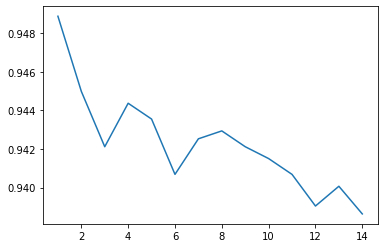

```python
knn_c = KNeighborsClassifier()
knn_c_cv = GridSearchCV(knn_c, param_grid, cv=10)
knn_c_cv.fit(X_c_train, y_c_train)

plt.plot(range(1, 15),knn_c_cv.cv_results_['mean_test_score'])
```

```python
knn_ = KNeighborsClassifier(n_neighbors = 1)
knn_c.fit(X_c_train,y_c_train)
print("Le score de kkn_c sur le jeu de test vaut {}.".format(knn_1.score(X_test, y_test)))
```

```
Le score de kkn_c sur le jeu de test vaut 0.9353846153846154.
```

=> Est-ce que ça vaut le coup d'ajouter ces variables et de perdre en interprétabilité ? Pas vraiment !

```python
# François Hu
from sklearn.model_selection import train_test_split
X_train_all, X_test_all, y_train_all, y_test_all = train_test_split(data.drop(columns='color'),
                                                    data['color'])

X_train_, y_train_ = balanced_data(X_train_all, y_train_all)
X_test_, y_test_ = balanced_data(X_test_all, y_test_all)

f_ = LogisticRegression()
f_.fit(X_train_, y_train_)
print('Régression logistique:',f_.score(X_test_,y_test_))

perceptron_ = Perceptron()
perceptron_.fit(X_train_,y_train_)
print('Perceptron', perceptron_.score(X_test_,y_test_))

knn_ = {}
score_train = []
score_test = []
k_range = range(1,20)
for k in k_range:
    knn_[k] =  KNeighborsClassifier(n_neighbors=k)
    knn_[k].fit(X_train_,y_train_)
    score_test.append(knn_[k].score(X_test_,y_test_))
k_best = np.argmax(score_test)
print('Meilleur kNN', score_test[k_best])
```

[output not shown]

```
Régression logistique: 0.972636815920398
Perceptron 0.9079601990049752
Meilleur kNN 0.9266169154228856
```

## Partie 2 : K-NN et Validation croisée

```python
import matplotlib.pyplot as plt
import numpy as np
```

On va continuer à utiliser kNN et Validation croisée et on utilise un autre jeu de données célèbre.

On considère un problème de reconnaissance de caractères. Le jeu de données contient des images de chiffres manuscrits, ainsi que le chiffre correspondant. On souhaite construire un prédicteur qui sache reconnaître le chiffre à partir de l’image. Il s’agit donc d’un problème de classification. On charge le jeu de données.

```python
from sklearn import datasets
digits = datasets.load_digits()
X = digits.data
y = digits.target
print(X)
print(X[1])
```

```
[[ 0.  0.  5. ...  0.  0.  0.]
 [ 0.  0.  0. ... 10.  0.  0.]
 [ 0.  0.  0. ... 16.  9.  0.]
 ...
 [ 0.  0.  1. ...  6.  0.  0.]
 [ 0.  0.  2. ... 12.  0.  0.]
 [ 0.  0. 10. ... 12.  1.  0.]]
[ 0.  0.  0. 12. 13.  5.  0.  0.  0.  0.  0. 11. 16.  9.  0.  0.  0.  0.
  3. 15. 16.  6.  0.  0.  0.  7. 15. 16. 16.  2.  0.  0.  0.  0.  1. 16.
 16.  3.  0.  0.  0.  0.  1. 16. 16.  6.  0.  0.  0.  0.  1. 16. 16.  6.
  0.  0.  0.  0.  0. 11. 16. 10.  0.  0.]
```

Chaque chiffre de 0 à 9 est décrit par un vecteur de taille 64.

On peut voir que chaque entrée, par exemple X[1] ci-dessus, est un array de dimension 1 et de taille 64. Il représente une image de taille 8 x 8 pixels. Chaque composante est un entier compris entre 0 et 16 et représente l’intensité de gris du pixel correspondant. Pour chaque entrée, on peut utiliser la fonction .reshape() afin d’en faire un array de dimension 2 et de taille 8 x 8.

```python
print(X[1].reshape(8,8))
```

```
[[ 0.  0.  0. 12. 13.  5.  0.  0.]
 [ 0.  0.  0. 11. 16.  9.  0.  0.]
 [ 0.  0.  3. 15. 16.  6.  0.  0.]
 [ 0.  7. 15. 16. 16.  2.  0.  0.]
 [ 0.  0.  1. 16. 16.  3.  0.  0.]
 [ 0.  0.  1. 16. 16.  6.  0.  0.]
 [ 0.  0.  1. 16. 16.  6.  0.  0.]
 [ 0.  0.  0. 11. 16. 10.  0.  0.]]
```

Cela permet ensuite de visualiser l’image correspondante grâce à la fonction plt.imshow().

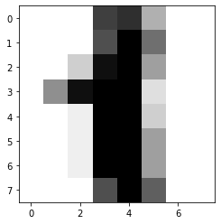

```python
plt.figure()
plt.imshow(X[1].reshape(8,8),cmap=plt.cm.gray_r)
plt.show()
```

Il s'agit vraisemblablement d'un 1.

### Q12.

Question 12. — Les différentes classes (0; 1; ... ; 8 et 9) sont-elles présentes en quantités à peu près égales dans le jeu de données ?

```python
print(y)
```

```
[0 1 2 ... 8 9 8]
```

```python
for i in range(0,10):
    print('Chiffre',i,':', sum(y==i))
```

```
Chiffre 0 : 178
Chiffre 1 : 182
Chiffre 2 : 177
Chiffre 3 : 183
Chiffre 4 : 181
Chiffre 5 : 182
Chiffre 6 : 181
Chiffre 7 : 179
Chiffre 8 : 174
Chiffre 9 : 180
```

Les classes sont à peu près équilibrées.

Nous allons construire des prédicteurs kNN. Les prédictions de ces derniers sont lentes à calculer lorsque l’échantillon d’apprentissage est grand. On va donc tenter de limiter la taille de l’échantillon d’apprentissage.

### Q13.

Question 13. — Partitionner le jeu de données en deux échantillons: un échantillon (X_cv, y_cv) de taille 200, qui servira pour la validation croisée, et un échantillon de test (X_test, y_test) qui servira pour le test final.

On pensera à utiliser la fonction train_test_split vue dans le TP précédent, dans laquelle on pourra spécifier l’argument optionnel train_size.

=> Ici on a 10 étiquettes possibles, ca veut dire seulement 20 exemple pour chaque chiffre. C'est peu, on peut pas trop descendre davantage en dessous de 200.

```python
from sklearn.model_selection import train_test_split
X_cv, X_test, y_cv, y_test = train_test_split(X, y, train_size=200)
```

```python
for i in range(0,10):
    print('Chiffre',i,':', sum(y_cv==i))
```

```
Chiffre 0 : 22
Chiffre 1 : 20
Chiffre 2 : 17
Chiffre 3 : 16
Chiffre 4 : 18
Chiffre 5 : 15
Chiffre 6 : 24
Chiffre 7 : 21
Chiffre 8 : 30
Chiffre 9 : 17
```

Nous pouvons à présent effectuer une validation croisée sur l’échantillon (X_cv,y_cv). Nous allons par exemple considérer l’algorithme kNN avec k = 5, et une 7-validation croisée. Nous faisons appel à la fonction cross_val_score, fournie par scikit-learn.

### Q14.

Question 14. — Que contient la variable scores définie ci-dessous ? En déduire le score de validation de la 7-CV de l’algorithme 5NN.

```python
from sklearn.neighbors import KNeighborsClassifier
from sklearn.model_selection import cross_val_score

knn = KNeighborsClassifier(n_neighbors=5)
scores = cross_val_score(knn, X_cv, y_cv, cv=7) #6 à l'apprentissage et 1 à la validation.

print(scores)
```

```
[0.89655172 0.93103448 0.93103448 0.89655172 0.89285714 1.
 0.92857143]
```

On calcule le score du prédicteur des 5 plus proches voisins pour X_cross_val et Y_cross_val. On sépare en 7 blocs. Ex 2e resultat = 2e sert de test et les autres sert d'entraînement. Et le score de la validation croisée est la moyenne de ces scores. On réduit la variance par rapport à un seul jeu de données.

`scores` contient les scores de validation pour chacun des 7 couples d'échantillons apprentissage/validation considérés par la 7-CV. Le score final de la 7-CV est donc la moyenne de ces 7 scores.

```python
print("Score de validation de la 7-CV de l'algorithme 5NN: ",  np.mean(scores))
```

[output not shown]

Pour un ensemble de valeurs de l’hyperparamètre k (par exemple k appartient à {1, ..., 20}), les scores d’apprentissage et de validation de la 7-CV peuvent se calculer comme suit.

### Q15.

Question 15. — Tracer les courbes de validation correspondantes. Y a-t-il besoin d’essayer d’autres valeurs de k? Définir une variable k_best égale à la meilleure valeur de l’hyperparamètre k selon ce qui précède.

```python
from sklearn.model_selection import validation_curve
k_range = range(1,21)
train_scores, valid_scores = validation_curve(KNeighborsClassifier(),
                                              X_cv,
                                              y_cv,
                                              "n_neighbors",
                                              k_range,
                                              cv=7)
```

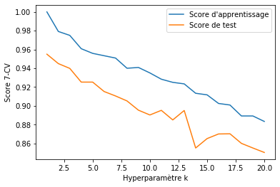

```python
train_mean_score = np.mean(train_scores,axis=1)
valid_mean_score = np.mean(valid_scores,axis=1)

plt.plot(k_range, train_mean_score, label='Score d\'apprentissage')
plt.plot(k_range, valid_mean_score, label='Score de test')
plt.xlabel("Hyperparamètre k")
plt.ylabel("Score 7-CV")
plt.legend()
plt.show()
```

```python
k_best = k_range[np.argmax(valid_mean_score)]
k_best
```

```
1
```

Pour les grandes valeurs de k considérées, on voit que les scores d'apprentissage et de test décroissent toutes les deux lorsque k croît. De plus, on sait que le biais de l'algorithme kNN augmente lorsque k croît. On en déduit qu'il y a sous-apprentissage (underfitting) pour les grandes valeurs de k. Il est donc inutile de considérer des valeurs k encore plus grandes.

Sous-apprentissage : si le nombre de voisins est trop grand, les scores d'apprentissage et de tests sont mauvais. On lisse trop le nombre de réponses donc le meilleur voisin semble être 1... Donc on a pas besoin de passer à plus de 20 voisins.

De plus, on a à peu près 20 instances pour chaque chiffre donc si on ajoute plus de 20 voisins on peut être sûr d'avoir un individu mauvais dans les voisins.

On souhaite, pour k = k_best, tracer la courbe d’apprentissage correspondant à des tailles d’échantillon d’apprentissage allant de 10 à 150, et multiples de 5.

### Q16.

Question 16. — Tracer la courbe d’apprentissage correspondante. Serait-il intéressant d’utiliser des échantillons d’apprentissage de plus grande taille? Si oui, reprendre depuis la question 2 avec un plus grand échantillon d’apprentissage.

Courbe d'apprentissage correspondante.

```python
from sklearn.model_selection import learning_curve

train_size_range = range(10,151,5)
train_sizes, train_scores, valid_scores = learning_curve(
    KNeighborsClassifier(n_neighbors=k_best),
    X_cv,y_cv,train_sizes=train_size_range,
    cv=7)
```

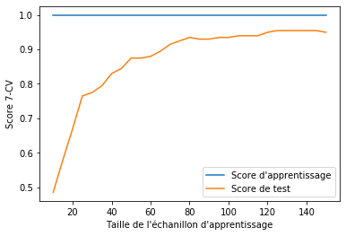

```python
train_mean_score = np.mean(train_scores,axis=1)
valid_mean_score = np.mean(valid_scores,axis=1)

plt.plot(train_sizes, train_mean_score, label='Score d\'apprentissage')
plt.plot(train_sizes, valid_mean_score, label='Score de test')
plt.xlabel("Taille de l'échanillon d'apprentissage")
plt.ylabel("Score 7-CV")
plt.legend()
plt.show()
```

On voit que la courbe de score de test atteint ici un plateau (les résultats peuvent varier). Il est donc inutile de considérer des échantillons d'apprentissage plus grands.

A partir de 110, ça n'augmente plus considérablement, or la taille max de l'apprentissage est 200. A chaque fois on a 6 blocs d'apprentissages donc environ 175 entrées, ce qui est suffisant pour que notre algorithme prédise correctement la valeur demandée. Donc cela sert à rien d'augmenter le nb de données d'entraînement : on a déjà atteint un plateau.

### Q17.

Question 17. — Tracer une courbe d’apprentissage où le score est obtenu par validation simple, et non par validation croisée. Expliquer l’avantage de la validation croisée dans ce contexte.

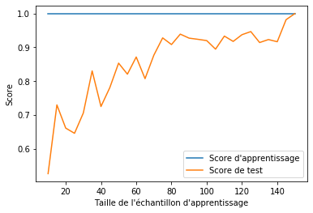

```python
import numpy as np

knn_dict = {}
score_train = []
score_test = []

for size in train_size_range:
    X_train_,X_test_,y_train_,y_test_ = train_test_split(X_cv,y_cv,train_size=size) #jeu d'entraînement et test
    knn_dict[size] = KNeighborsClassifier(n_neighbors=k_best).fit(X_train_,y_train_) #on teste sur jeu de test
    score_train.append(knn_dict[size].score(X_train_,y_train_))
    score_test.append(knn_dict[size].score(X_test_,y_test_))

plt.plot(train_size_range, score_train, label='Score d\'apprentissage')
plt.plot(train_size_range, score_test, label='Score de test')
plt.xlabel("Taille de l'échantillon d'apprentissage")
plt.ylabel("Score")
plt.legend()
plt.show()
```

Le score de la validation croisée est obtenue par la moyenne de plusieurs (ici 7) scores de validation simple. Elle présente donc beaucoup moins de fluctuations, et permet, ici pour la lecture des courbes d'apprentissage, de mieux saisir le comportement des courbes.

### Q18.

Question 18. — Entraîner le prédicteur kNN (pour k =k_best) avec (X_cv,y_cv) pour échantillon d’apprentissage. Calculer son score de test avec l’échantillon (X_test,y_test). Observer également la matrice de confusion sur l’échantillon de test. Quelle est l’erreur de classification la plus fréquente?

```python
knn_best = KNeighborsClassifier(n_neighbors=k_best).fit(X_cv,y_cv) #rappel : k_best = 1
print('Score :',knn_best.score(X_test,y_test))
```

```
Score : 0.9461490294301816
```

Ce score est quand même assez important.

```python
import pandas as pd
pd.crosstab(y_test,knn_best.predict(X_test))
```

| col_0 row_0 | 0 | 1 | 2 | 3 | 4 | 5 | 6 | 7 | 8 | 9 |
| --- | --- | --- | --- | --- | --- | --- | --- | --- | --- | --- |
| 0 | 155 | 0 | 0 | 0 | 1 | 0 | 0 | 0 | 0 | 0 |
| 1 | 0 | 151 | 0 | 0 | 2 | 0 | 1 | 0 | 2 | 6 |
| 2 | 1 | 2 | 146 | 1 | 0 | 0 | 0 | 1 | 9 | 0 |
| 3 | 0 | 0 | 2 | 156 | 0 | 2 | 0 | 3 | 4 | 0 |
| 4 | 0 | 0 | 0 | 0 | 158 | 1 | 0 | 1 | 0 | 3 |
| 5 | 0 | 0 | 0 | 2 | 2 | 154 | 2 | 0 | 2 | 5 |
| 6 | 0 | 2 | 0 | 0 | 0 | 0 | 154 | 0 | 1 | 0 |
| 7 | 0 | 0 | 0 | 0 | 0 | 0 | 0 | 153 | 4 | 1 |
| 8 | 0 | 9 | 1 | 1 | 0 | 1 | 0 | 0 | 132 | 0 |
| 9 | 0 | 0 | 0 | 3 | 0 | 1 | 1 | 0 | 6 | 152 |

On souhaite à présent ajouter au jeu de données des exemples obtenus par modification des exemples existants, dans l’espoir d’obtenir de meilleurs résultats.

### Q19.

Question 19. — Écrire une fonction shift_image qui prend un argument un array (nommé image) de dimension 2 et de taille 8  8 (représentant une image), ainsi qu’un array (nommé direction) contenant des entiers de dimension 1 de taille 2, et qui renvoie l’image translatée par le vecteur de coordonnées direction (le contenu de l’image est donc amené à être rogné sur certains côtés). Vérifier le bon fonctionnement de la fonction en visualisant quelques images translatées.

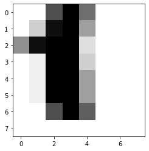

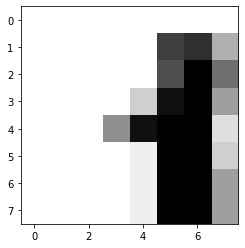

```python
def shift_image(image,direction):
    dx, dy = direction
    x_shifted_image = np.zeros((8,8))
    if dx > 0:
        x_shifted_image[:,dx:] = image[:,:-dx]
    elif dx < 0:
        x_shifted_image[:,:dx] = image[:,-dx:]
    else:
        x_shifted_image = image
    xy_shifted_image = np.zeros((8,8))
    if dy > 0:
        xy_shifted_image[:-dy] = x_shifted_image[dy:]
    elif dy < 0:
        xy_shifted_image[-dy:] = x_shifted_image[:dy]
    else:
        xy_shifted_image = x_shifted_image
    return xy_shifted_image

plt.figure()
plt.imshow(shift_image(X[1].reshape(8,8),np.array([-1,1])),cmap=plt.cm.gray_r)
plt.show()

plt.figure()
plt.imshow(shift_image(X[1].reshape(8,8),np.array([2,-1])),cmap=plt.cm.gray_r)
plt.show()
```

On a la même image mais décalée de 1.

### Q20.

Question 20. — Ajouter au jeu de données la translation de tous les exemples par chacun des vecteurs: (-1; 0), (1; 0), (0;-1), (0; 1), (-1;-1), (-1; 1), (1;-1) et (1; 1). Construire alors un prédicteur kNN en choisissant l’hyperparamètre k par validation croisée, et observer son score sur un échantillon de test. Comparer le prédicteur obtenu à celui de la question 7. On pourra dans un premier temps utiliser un échantillon de validation croisée de taille 400, et décider ensuite s’il est intéressant d’en augmenter la taille.

```python
X_augmented = np.empty((0,64))
y_augmented = np.empty((0,1))

foo = [-1,0,1]
for dx in foo:
    for dy in foo:
        X_augmented = np.append(X_augmented,[shift_image(x.reshape(8,8),np.array([dx,dy])).reshape(64) for x in X],axis=0)
        y_augmented = np.append(y_augmented,y)
```

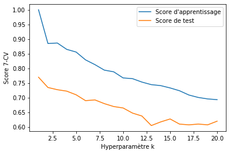

```
1
```

```python
X_augmented_train, X_augmented_test, y_augmented_train, y_augmented_test = train_test_split(X_augmented,y_augmented,train_size=400)

from sklearn.model_selection import validation_curve
k_range = range(1,21)
train_scores, valid_scores = validation_curve(KNeighborsClassifier(),
                                              X_augmented_train,
                                              y_augmented_train,
                                              "n_neighbors",
                                              k_range,
                                              cv=7)

train_mean_score = np.mean(train_scores,axis=1)
valid_mean_score = np.mean(valid_scores,axis=1)

plt.plot(k_range, train_mean_score, label='Score d\'apprentissage')
plt.plot(k_range, valid_mean_score, label='Score de test')
plt.xlabel("Hyperparamètre k")
plt.ylabel("Score 7-CV")
plt.legend()
plt.show()

k_best = k_range[np.argmax(valid_mean_score)]
k_best
```

On a encore k optimal vaut 1.

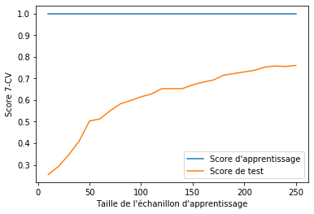

```python
train_size_range = range(10,251,10)
train_sizes, train_scores, valid_scores = learning_curve(
    KNeighborsClassifier(n_neighbors=k_best),
    X_augmented_train,y_augmented_train,train_sizes=train_size_range,
    cv=7)

train_mean_score = np.mean(train_scores,axis=1)
valid_mean_score = np.mean(valid_scores,axis=1)

plt.plot(train_sizes, train_mean_score, label='Score d\'apprentissage')
plt.plot(train_sizes, valid_mean_score, label='Score de test')
plt.xlabel("Taille de l'échanillon d'apprentissage")
plt.ylabel("Score 7-CV")
plt.legend()
plt.show()
```

Le score d'apprentissage reste très élevé. Le score de test est nettement inférieur, continue d'augmenter avec avec la taille de l'échantillon d'apprentissage. On est donc en situation de sur-apprentissage (overfitting). Il serait intéressant d'augmenter la taille de l'échantillon d'apprentissage. Travaillons avec un échantillon d'apprentissage/validation de taille 15000.

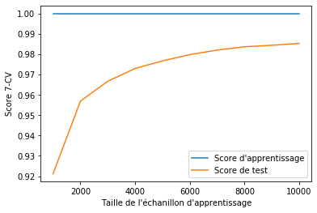

```python
X_augmented_train, X_augmented_test, y_augmented_train, y_augmented_test = train_test_split(X_augmented,y_augmented,train_size=15000)

train_size_range = range(1000,10001,1000)
train_sizes, train_scores, valid_scores = learning_curve(
    KNeighborsClassifier(n_neighbors=k_best),
    X_augmented_train,y_augmented_train,train_sizes=train_size_range,
    cv=7)

train_mean_score = np.mean(train_scores,axis=1)
valid_mean_score = np.mean(valid_scores,axis=1)

plt.plot(train_sizes, train_mean_score, label='Score d\'apprentissage')
plt.plot(train_sizes, valid_mean_score, label='Score de test')
plt.xlabel("Taille de l'échanillon d'apprentissage")
plt.ylabel("Score 7-CV")
plt.legend()
plt.show()
```

La courbe du score de test semble (presque) atteindre un plateau. Il semble donc que nous ayons un échantillon d'apprentissage/validation suffisamment grand. Cronstruisons à présent notre estimateur kNN sur l'ensemble de cet échantillon, et examions son score sur l'échantillon de test.

On voit que le plateau est autour de 6000 (entre 6000 et 10000).

```python
print('Score :',KNeighborsClassifier(n_neighbors=k_best).fit(X_augmented_train,y_augmented_train).score(X_augmented_test,y_augmented_test))
```

```
Score : 0.9863597612958227
```

Le prédicteur obtenu est meilleur sur les données augmentées que sur les données non augmentées.

C'est intuitif. 2 instances du même chiffres dont une est décalées ont une grande distance euclidienne. Mais c'est plus le cas ici avec les plus proches voisins : c'est pourquoi le score est bien meilleur.